# Cell-cell Communication for Signaling Pathways from Spatially Resolved Transcriptomics Data Realted to Alzheimer’s Disease

07 May, 2024

```r
library(TWCOM)
library(CellChat)
library(data.table)
library(dplyr)
subpath <- "./Alzheimer"
```

This vignette demonstrates `TWCOM`’s application to single-cell resolution spatially resolved transcriptomics (SRT) data, specifically in mice brain tissues with or without Alzheimer’s disease. The corresponding dataset can be accessed via [Zenodo](https://doi.org/10.5281/zenodo.7332091).

# 1 Data and preprocessing

## 1.1 Load data

```r
# normalized gene expression matrix
spdat <- as.data.frame(fread(paste0(subpath, "/Data/expression_matrix_normalized.csv"),
                             header=TRUE))
# metadata
spmeta <- as.data.frame(fread(paste0(subpath, "/Data/metadata.csv"), header=TRUE)[-1, ])
# spatial location
spfile <- list.files(paste0(subpath, "/Data/"), "spatial")
splist <- vector(mode="list", length=length(spfile))
for(i in 1:length(spfile)) {
    splist[[i]] <- as.data.frame(fread(paste0(subpath, "/Data/", spfile[i]),
                                       header=TRUE)[-1, ])
    for(j in 2:5) {
        splist[[i]][, j] <- as.numeric(splist[[i]][, j])
    }
}
splist_comb <- do.call("rbind", splist)
# combined with metadata and check the order of cells
spmeta <- left_join(spmeta, splist_comb[, 1:5], by="NAME")
rownames(spdat) <- spdat[, 1]
spdat <- spdat[, -1]
spmeta <- spmeta[order(match(spmeta$NAME, colnames(spdat))), ]
rownames(spmeta) <- spmeta$NAME
```

## 1.2 Filtering

```r
keepposi <- which(spmeta$time == "13months")
spdat <- spdat[, keepposi]
spmeta <- spmeta[keepposi, ]
keepposi <- which(apply(spdat, 2, function(x) sum(x != 0)) > 100)
spdat <- spdat[, keepposi]
spmeta <- spmeta[keepposi, ]
rmgene <- which(apply(spdat, 1, function(x) sum(x!=0)) < (ncol(spdat) * 0.025))
spdat <- spdat[-rmgene, ]
# separate disease vs. control
posi_AD <- which(spmeta$group == "disease")
spdat_AD <- spdat[, posi_AD]
spmeta_AD <- spmeta[posi_AD, ]
posi_CON <- which(spmeta$group == "control")
spdat_CON <- spdat[, posi_CON]
spmeta_CON <- spmeta[posi_CON, ]
```

## 1.3 Load ligand-receptor pairs and signaling pathways

We obtained the information using `CellChat`.

```r
lrdb <- CellChatDB.mouse
ligands <- receptors <- vector(mode="list", length=nrow(lrdb$interaction))

for(i in 1:length(ligands)) {

    if(!(lrdb$interaction$ligand[i] %in% rownames(lrdb$complex))) {
        ligands[[i]] <- lrdb$interaction$ligand[i]
    } else {
        ltemp <- c(lrdb$complex[rownames(lrdb$complex) == lrdb$interaction$ligand[i], ])
        ltemp <- ltemp[nzchar(ltemp)]
        ligands[[i]] <- ltemp
    }

    if(!(lrdb$interaction$receptor[i] %in% rownames(lrdb$complex))) {
        receptors[[i]] <- lrdb$interaction$receptor[i]
    } else {
        ltemp <- c(lrdb$complex[rownames(lrdb$complex) == lrdb$interaction$receptor[i], ])
        ltemp <- ltemp[nzchar(ltemp)]
        receptors[[i]] <- ltemp
    }

}
ligands <- lapply(ligands, unlist)
receptors <- lapply(receptors, unlist)
pathways <- lrdb$interaction$pathway_name
```

## 1.4 Obtain cell type idenfitication matrix

We can first check the cell type information for AD and CON, separately.

```r
table(spmeta_AD$top_level_cell_type)
```

```
#>
#>  Astro    CA1    CA2    CA3 CTX-Ex     DG   Endo    Inh    LHb  Micro  Oligo
#>   1003   1564    197    904   3175   3271    452    872     39    769   1829
#>    OPC    SMC
#>    233    311
```

```r
table(spmeta_CON$top_level_cell_type)
```

```
#>
#>  Astro    CA1    CA2    CA3 CTX-Ex     DG   Endo    Inh    LHb  Micro  Oligo
#>    581   1092    258    701   3515   2105    341    886     99    254   1077
#>    OPC    SMC
#>    163    262
```

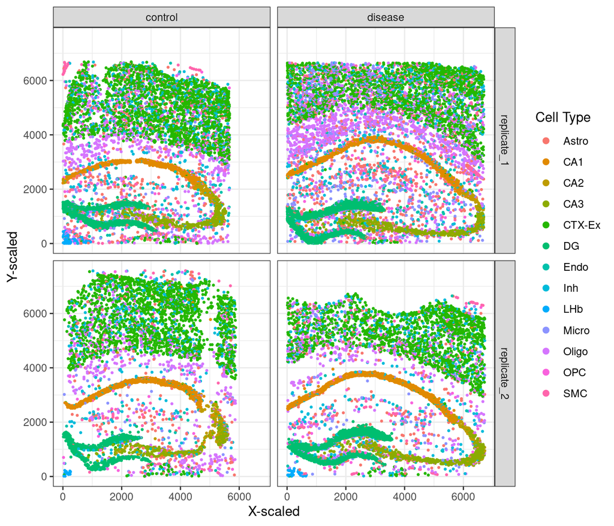

```r
ggplot(spmeta, aes(x=`X-scaled`, y=`Y-scaled`, color=top_level_cell_type)) +
  geom_point(size=0.5) + theme_bw() +
  facet_grid(replicate ~ group) +
  guides(colour = guide_legend(override.aes = list(size=2))) +
  labs(color = "Cell Type")
```

```r
Mnew_AD <- CellTypeMatrix(stmeta=spmeta_AD, celltype="top_level_cell_type")
Mnew_CON <- CellTypeMatrix(stmeta=spmeta_CON, celltype="top_level_cell_type")
```

# 2 Inferring cell-cell communication

The necessary inputs for `FRETCOMPathway()` include the normalized gene expression matrix (`stdat`), the cell type proportion matrix (`M`), the X and Y coordinates (`coordx` and `coordy`), the known ligand-receptor pairs (`ligands` and `receptors`), the known corresponding pathway names (`pathways`), and the maximum distance allowed for communication (`maxdist`). It is important to note that a reasonable `maxdist` should be set based on the units of `coordx` and `coordy` provided.

```r
restab_AD <- FRETCOMPathway(stdat=spdat_AD, M=Mnew_AD, ligands=ligands,
                            receptors=receptors, pathways=pathways,
                            sampleid=spmeta_AD$replicate,
                            coordx=spmeta_AD$`X-scaled`, coordy=spmeta_AD$`Y-scaled`,
                            maxdist=200, rholist=c(0.03, 0.05),
                            parallel=TRUE, ncores=8)
```

```
#> 2784 out of 3379 LR pairs have been removed due to their non-existence in SRT data.
#> 50 out of 67 signaling pathways have been removed due to a lack of gene expression information in SRT data.
#> 80 out of 169 cell type interactions have been removed due to a lack of information.
#>
```

```r
restab_CON <- FRETCOMPathway(stdat=spdat_CON, M=Mnew_CON, ligands=ligands,
                             receptors=receptors, pathways=pathways,
                             sampleid=spmeta_CON$replicate,
                             coordx=spmeta_CON$`X-scaled`, coordy=spmeta_CON$`Y-scaled`,
                             maxdist=200, rholist=c(0.03, 0.05),
                             parallel=TRUE, ncores=8)
```

```
#> 2784 out of 3379 LR pairs have been removed due to their non-existence in SRT data.
#> 55 out of 67 signaling pathways have been removed due to a lack of gene expression information in SRT data.
#> 82 out of 169 cell type interactions have been removed due to a lack of information.
```

We can check the pathways for disease group and control group, separately:

```r
unique(restab_AD$Pathway)   # disease group
```

```
#>  [1] "CCL"       "SEMA3"     "LAMININ"   "VTN"       "TENASCIN"  "APP"
#>  [7] "CADM"      "CNTN"      "NRXN"      "PTPR"      "SLITRK"    "ADGRB"
#> [13] "ADGRL"     "GABA-A"    "GABA-B"    "Glutamate" "CypA"      "Overall"
```

```r
unique(restab_CON$Pathway)   # control group
```

```
#>  [1] "SEMA3"     "LAMININ"   "CADM"      "CNTN"      "NRXN"      "PTPR"
#>  [7] "ADGRB"     "ADGRL"     "GABA-A"    "GABA-B"    "Glutamate" "CypA"
#> [13] "Overall"
```

# 3 Network Visualization

We focus on the LAMININ signaling pathway as an example for cellular communication network visualization. Although the built-in function `CCCNetwork()` can provide an easy way to demonstrate the results, we prefer to generate the plots manually for better visualization.

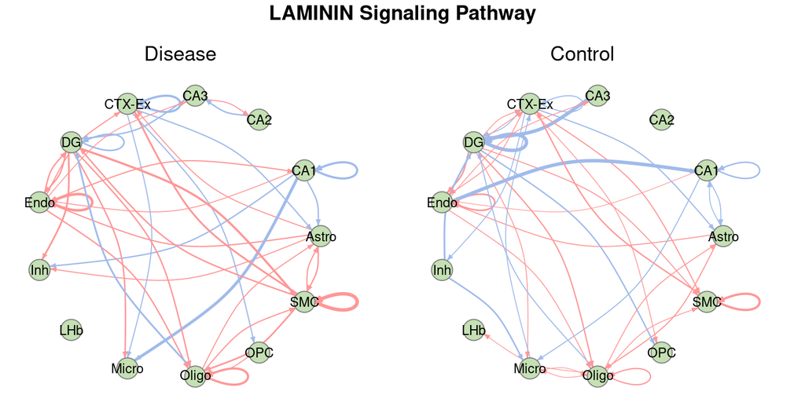

```r
# filter the results
cutoff <- 0.05
weight <- 50
pathname <- "LAMININ"
tempres_AD <- restab_AD[restab_AD$Pathway == pathname, ]
tempres_AD$Qvalue[is.nan(tempres_AD$Qvalue)] <- 1
tempres_AD <- tempres_AD[tempres_AD$Qvalue < cutoff, ]
tempres_AD$Estimate[tempres_AD$Estimate < -0.1] <- -0.1
tempres_AD$Estimate[tempres_AD$Estimate > 0.1] <- 0.1
tempres_CON <- restab_CON[restab_CON$Pathway == pathname, ]
tempres_CON$Qvalue[is.nan(tempres_CON$Qvalue)] <- 1
tempres_CON <- tempres_CON[tempres_CON$Qvalue < cutoff, ]
tempres_CON$Estimate[tempres_CON$Estimate < -0.1] <- -0.1
tempres_CON$Estimate[tempres_CON$Estimate > 0.1] <- 0.1
# obtain cell types
all_celltype <- unique(c(tempres_AD$CellType_Sender, tempres_AD$CellType_Receiver,
                         tempres_CON$CellType_Sender, tempres_CON$CellType_Receiver))
all_celltype <- all_celltype[order(all_celltype)]
# set up the network matrix
netm_AD <- matrix(0, nrow=length(all_celltype), ncol=length(all_celltype))
for (i in 1:length(all_celltype)) {
  for (j in 1:length(all_celltype)) {
    if (any(tempres_AD$CellType_Sender == all_celltype[i] & tempres_AD$CellType_Receiver == all_celltype[j]))
    netm_AD[i, j] <- tempres_AD$Estimate[tempres_AD$CellType_Sender == all_celltype[i] & tempres_AD$CellType_Receiver == all_celltype[j]]
  }
}
row.names(netm_AD) <- all_celltype
colnames(netm_AD) <- all_celltype
netm_CON <- matrix(0, nrow=length(all_celltype), ncol=length(all_celltype))
for (i in 1:length(all_celltype)) {
  for (j in 1:length(all_celltype)) {
    if (any(tempres_CON$CellType_Sender == all_celltype[i] & tempres_CON$CellType_Receiver == all_celltype[j]))
      netm_CON[i, j] <- tempres_CON$Estimate[tempres_CON$CellType_Sender == all_celltype[i] & tempres_CON$CellType_Receiver == all_celltype[j]]
  }
}
row.names(netm_CON) <- all_celltype
colnames(netm_CON) <- all_celltype
# prepare for the networks
net_AD <- graph_from_adjacency_matrix(netm_AD, mode="directed", weighted=TRUE)
E(net_AD)$color[E(net_AD)$weight < 0] <- '#a0bbeb'
E(net_AD)$color[E(net_AD)$weight > 0] <- '#FF9797'
E(net_AD)$weight <- abs(E(net_AD)$weight)
edge.weight.max <- max(E(net_AD)$weight)
E(net_AD)$width<- 0.3+E(net_AD)$weight/edge.weight.max * 3
net_CON <- graph_from_adjacency_matrix(netm_CON, mode="directed", weighted=TRUE)
E(net_CON)$color[E(net_CON)$weight < 0] <- '#a0bbeb'
E(net_CON)$color[E(net_CON)$weight > 0] <- '#FF9797'
E(net_CON)$weight <- abs(E(net_CON)$weight)
edge.weight.max <- max(E(net_CON)$weight)
E(net_CON)$width<- 0.3+E(net_CON)$weight/edge.weight.max * 3
# draw network plots
par(mfrow=c(1, 2), mar=c(0, 0, 0, 0))
plot(net_AD,
     vertex.color="#C5E0B4",
     vertex.label.color="black",
     ertex.size=15,
     vertex.label.font=1.8,
     vertex.label.family="sans",
     vertex.frame.color="gray50",
     vertex.label.cex=0.8,
     edge.arrow.size=0.3,
     edge.curved=0.3,
     layout=layout_in_circle,
     margin=c(0, 0, 0.5, 0.3))
text(0, 1.3, "Disease", cex=1.2)
plot(net_CON,
     vertex.color="#C5E0B4",
     vertex.label.color="black",
     vertex.size=15,
     vertex.label.font=1.8,
     vertex.label.family="sans",
     vertex.frame.color="gray50",
     vertex.label.cex=0.8,
     edge.arrow.size=0.3,
     edge.curved=0.3,
     layout=layout_in_circle,
     margin=c(0, 0, 0.5, 0.3))
text(0, 1.3, "Control", cex=1.2)
title("LAMININ Signaling Pathway", line=-1, outer=TRUE)
```